# Understanding Michaelis–Menten Kinetics

Martin De Kauwe

# Introduction

Michaelis–Menten kinetics describes how the rate of an enzyme-catalyzed reaction depends on substrate concentration, capturing this relationship with two key parameters: the maximum reaction rate (V<sub>max</sub>) and the substrate concentration at which the reaction rate is half of V<sub>max</sub> (K<sub>m</sub>). This framework provides a useful analogy for understanding how Rubisco activity is influenced by CO<sub>2</sub> availability in C<sub>3</sub> photosynthesis.

```r
library(ggplot2)
```

We are going to start by describing our model as a function. A model is a simplified mathematical description of a process - in this case, how an enzyme’s reaction rate depends on substrate concentration. A function in R is a reusable block of code that takes inputs (called arguments), performs a calculation, and returns an output. Writing the model as a function makes it easy to apply the same formula to many different values or to reuse in other code

```r
michaelis_menten <- function(S, Vmax, Km) {
  # Model is after Leonor Michaelis and Maud Menten

  # S is the substrate
  # Vmax is the maximum reaction rate (i.e., when the enzyme is saturated)
  # Km is the Michaelis constant, the substrate concentration at half Vmax
  V <- Vmax * S / (Km + S)

  return (V)
}
```

Let’s now run our model…

```r
# Parameters
Vmax <- 1.5   # μmol/min/mg enzyme
Km <- 0.05    # mM

# Create an array of substrate concentrations (S, mM)
substrate_conc <- seq(0, 0.5, by=0.01)

# check what this looks like
print(substrate_conc)
```

```
##  [1] 0.00 0.01 0.02 0.03 0.04 0.05 0.06 0.07 0.08 0.09 0.10 0.11 0.12 0.13 0.14
## [16] 0.15 0.16 0.17 0.18 0.19 0.20 0.21 0.22 0.23 0.24 0.25 0.26 0.27 0.28 0.29
## [31] 0.30 0.31 0.32 0.33 0.34 0.35 0.36 0.37 0.38 0.39 0.40 0.41 0.42 0.43 0.44
## [46] 0.45 0.46 0.47 0.48 0.49 0.50
```

```r
# Compute reaction velocities
velocities <- michaelis_menten(substrate_conc, Vmax, Km)

# Create a data frame to make it easy to store the data and plot
df <- data.frame(
  substrate = substrate_conc,
  velocity = velocities
)
```

And make a plot to see how our model works

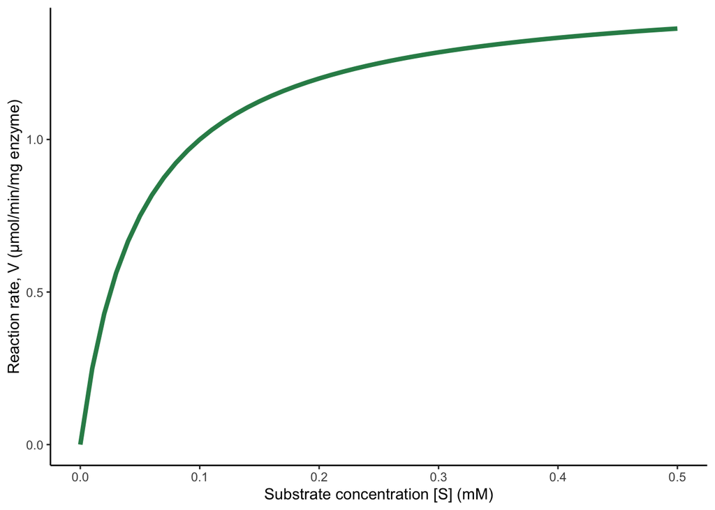

```r
ggplot(df, aes(x=substrate, y=velocity)) +
  geom_line(color = "seagreen", linewidth=1.5) +
  labs(
    x = "Substrate concentration [S] (mM)",
    y = "Reaction rate, V (μmol/min/mg enzyme)"
  ) +
  theme_classic()
```

## Questions

1. What happens to the reaction rate when the substrate concentration is low vs high?
2. If we change V<sub>max</sub> how does it affect our plot? Hint: Change V<sub>max</sub> and plot the old line and the new model prediction.
3. How does changing K<sub>m</sub> affect the affinity for the substrate? Hint: Change K<sub>m</sub> and plot the old line and the new model prediction.

## Summary

By exploring the Michaelis–Menten model, we have learned how enzyme reaction rates depend on substrate concentration and how the key parameters V<sub>max</sub> and K<sub>m</sub> influence the response. Altering V<sub>max</sub> modifies the maximum rate the enzyme can achieve, while adjusting K<sub>m</sub> affects how efficiently the enzyme binds to its substrate.